# Comparision of Risk in Investment in crypto and metaverse token

Ayan Bashir Sheikh

2024-05-12

```r
suppressWarnings({
library(readxl)
d1=read_xlsx("D:\\ST 402 Project\\data\\metaverse tokens\\four tokens\\Axie Infinity.xlsx")
d2=read_xlsx("D:\\ST 402 Project\\data\\metaverse tokens\\four tokens\\Decentraland.xlsx")
d3=read_xlsx("D:\\ST 402 Project\\data\\metaverse tokens\\four tokens\\Enjin.xlsx")
d4=read_xlsx("D:\\ST 402 Project\\data\\metaverse tokens\\four tokens\\Sandbox.xlsx")
BTC=read.csv("D:/ST 402 Project/data/B_E_L Metaverse Tokens/BTC_USD_2020-03-29-CoinDesk.csv")
ETH=read.csv("D:/ST 402 Project/data/B_E_L Metaverse Tokens/ETH_USD_2020-03-29-CoinDesk.csv")
LTC=read.csv("D:/ST 402 Project/data/B_E_L Metaverse Tokens/LTC_USD_2020-03-29-CoinDesk.csv")
colnames(LTC)=colnames(ETH)=colnames(BTC)=c("currency","Date","Close","Open","High","Low")
BTC$returns = c(0, diff(BTC$Close) / head(BTC$Close, -1))
ETH$returns = c(0, diff(ETH$Close) / head(ETH$Close, -1))
LTC$returns = c(0, diff(LTC$Close) / head(LTC$Close, -1))
})
```

```r
suppressWarnings({
library(PerformanceAnalytics)
VaR_95E = VaR(ETH$returns, p = 0.95, method = "historical");VaR_95E
CVaR_95E = ES(ETH$returns, p = 0.95, method = "historical");CVaR_95E
VaR_95B = VaR(BTC$returns, p = 0.95, method = "historical");VaR_95B
CVaR_95B = ES(BTC$returns, p = 0.95, method = "historical");CVaR_95B
VaR_95L = VaR(LTC$returns, p = 0.95, method = "historical");VaR_95L
CVaR_95L = ES(LTC$returns, p = 0.95, method = "historical");CVaR_95L
VaR_95A = VaR(d1$Return, p = 0.95, method = "historical");VaR_95A
CVaR_95A = ES(d1$Return, p = 0.95, method = "historical");CVaR_95A
VaR_95D = VaR(d2$Return, p = 0.95, method = "historical");VaR_95D
CVaR_95D = ES(d2$Return, p = 0.95, method = "historical");CVaR_95D
VaR_95En = VaR(d3$Return, p = 0.95, method = "historical");VaR_95En
CVaR_95En= ES(d3$Return, p = 0.95, method = "historical");CVaR_95En
VaR_95s= VaR(d4$Return, p = 0.95, method = "historical");VaR_95s
CVaR_95s = ES(d4$Return, p = 0.95, method = "historical");CVaR_95s


risk_measures = data.frame(
  Token = c("ETH", "BTC", "LTC", "Axie infinity", "Decentraland", "Enjin", "Sandbox"),
  VaR = c(VaR_95E, VaR_95B, VaR_95L, VaR_95A, VaR_95D, VaR_95En, VaR_95s),
  CVaR = c(CVaR_95E, CVaR_95B, CVaR_95L, CVaR_95A, CVaR_95D, CVaR_95En, CVaR_95s)
)


risk_measures


})
```

```
##           Token         VaR        CVaR
## 1           ETH -0.06859660 -0.10896281
## 2           BTC -0.05342919 -0.08864855
## 3           LTC -0.07514402 -0.11226267
## 4 Axie infinity -0.12117114 -0.16534219
## 5  Decentraland -0.11431650 -0.17017849
## 6         Enjin -0.10918033 -0.16748954
## 7       Sandbox -0.12068350 -0.17679551
```

**Ethereum` :** The historical VaR is -0.06859660 and the CVaR is -0.10896281. This means that, based on past data, the maximum loss expected from ETH in a day is 6.86% under normal market conditions. In the worst-case scenario (i.e., the worst 5% of cases), the expected loss is 10.90%.

**Bitcoin:** The historical VaR is -0.05342919 and the CVaR is -0.08864855. This means that, based on past data, the maximum loss expected from BTC in a day is 5.34% under normal market conditions. In the worst-case scenario, the expected loss is 8.86%.

**Litcoine:** The historical VaR is -0.07514402 and the CVaR is -0.11226267. This means that, based on past data, the maximum loss expected from LTC in a day is 7.51% under normal market conditions. In the worst-case scenario, the expected loss is 11.23%.

**Axie Infinity:** The historical VaR is -0.12117114 and the CVaR is -0.16534219. This means that, based on past data, the maximum loss expected from Axie Infinity in a day is 12.12% under normal market conditions. In the worst-case scenario, the expected loss is 16.53%.

**Decentraland:** The historical VaR is -0.11431650 and the CVaR is -0.17017849. This means that, based on past data, the maximum loss expected from Decentraland in a day is 11.43% under normal market conditions. In the worst-case scenario, the expected loss is 17.02%.

**Enjin:** The historical VaR is -0.10918033 and the CVaR is -0.16748954. This means that, based on past data, the maximum loss expected from Enjin in a day is 10.92% under normal market conditions. In the worst-case scenario, the expected loss is 16.75%.

**Sandbox:** The historical VaR is -0.12068350 and the CVaR is -0.17679551. This means that, based on past data, the maximum loss expected from Sandbox in a day is 12.07% under normal market conditions. In the worst-case scenario, the expected loss is 17.68%.

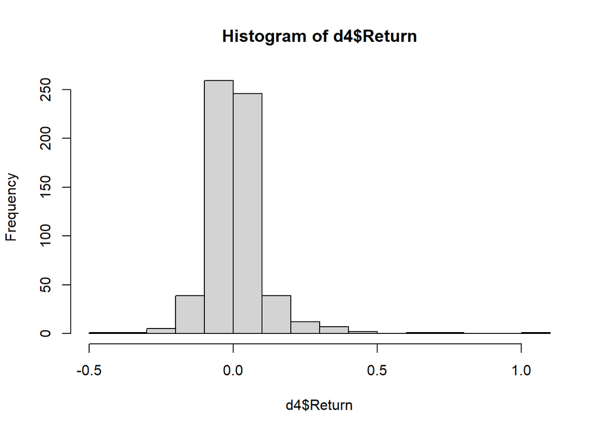

```r
hist(d4$Return)
```

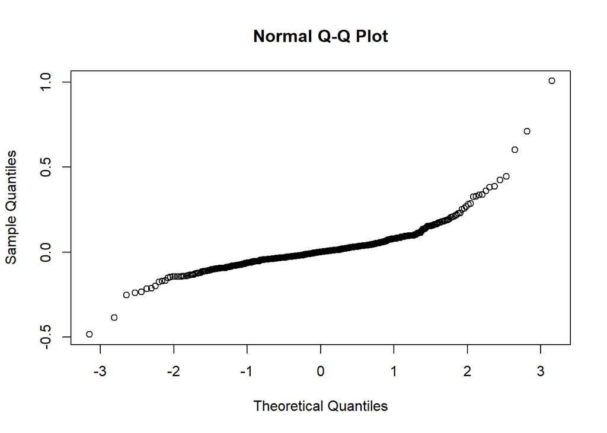

```r
qqnorm(d4$Return)
```

```r
shapiro.test(LTC$returns)
```

```
##
##  Shapiro-Wilk normality test
##
## data:  LTC$returns
## W = 0.92892, p-value = 3.315e-12
```